# Tugas Individu Analisis Regresi

Laras Suprapti G1401221044 2024-03-05

```r
library(dplyr)
```

```r
library(plotly)
library(lmtest)
library(car)
library(randtests)
```

# IMPORT DATA

```r
data <- read.csv("C:/Users/ASUS/OneDrive/Documents/data anreg indv.csv", sep=",")
data
```

```
##     X  Y
## 1   2 54
## 2   5 50
## 3   7 45
## 4  10 37
## 5  14 35
## 6  19 25
## 7  26 20
## 8  31 16
## 9  34 18
## 10 38 13
## 11 45  8
## 12 52 11
## 13 53  8
## 14 60  4
## 15 65  6
```

```r
model= lm(formula = Y ~ X, data = data)
summary(model)
```

```
##
## Call:
## lm(formula = Y ~ X, data = data)
##
## Residuals:
##     Min      1Q  Median      3Q     Max
## -7.1628 -4.7313 -0.9253  3.7386  9.0446
##
## Coefficients:
##             Estimate Std. Error t value Pr(>|t|)
## (Intercept) 46.46041    2.76218   16.82 3.33e-10 ***
## X           -0.75251    0.07502  -10.03 1.74e-07 ***
## ---
## Signif. codes:  0 '***' 0.001 '**' 0.01 '*' 0.05 '.' 0.1 ' ' 1
##
## Residual standard error: 5.891 on 13 degrees of freedom
## Multiple R-squared:  0.8856, Adjusted R-squared:  0.8768
## F-statistic: 100.6 on 1 and 13 DF,  p-value: 1.736e-07
```

# Scatter plot X vs Y

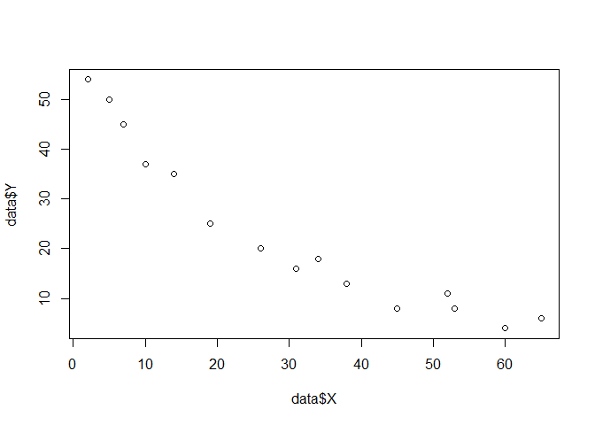

```r
plot(x = data$X, y = data$Y)
```

Berdasarkan scatter plot X vs Y di atas, terlihat bahwa bentuk persebaran tidak lurus dan cenderung membentuk parabola. Hal tersebut menandakan bahwa hubungan antara peubah X dan Y tidak linear. Jika tidak memenuhi asumsi-asumsi yang ada, maka data harus ditransformasi. Transformasi yang diperlukan jika scatter plotnya berbentuk seperti di atas, maka trasformasi yang dilakukan adalah dengan memperkecil x (mengakarkan X) atau memperkecil y (mengakarkan Y).

# Plot sisaan vs Y duga

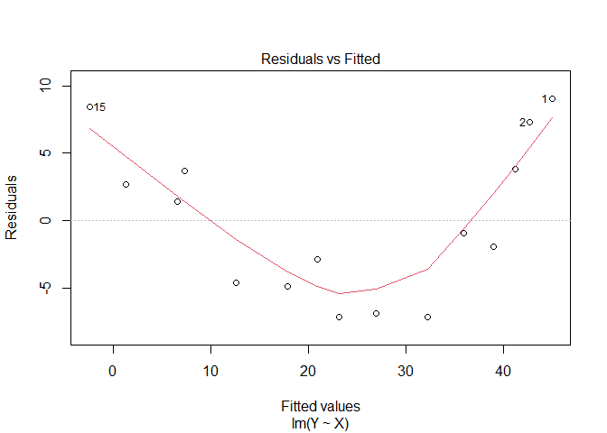

```r
plot(model,1)
```

sisaan disekitar 0 menandakan nilai harapan galat sama dengan nol. Lebar pita sama untuk setiap nilai dugaanyang menandakan ragam homogen. Namun, karena bentuk pola tebaran sisaan vs yduga berpola, yaitu pola kurva, maka tidak memenuhi asumsi kondisi Gauss-Markov.

# Plot Sisaan vs Urutan

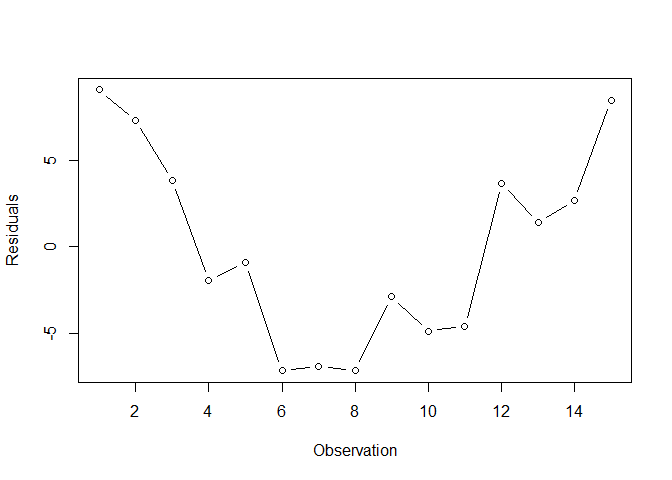

```r
plot(x = 1:dim(data)[1],
     y = model$residuals,
     type = 'b',
     ylab = "Residuals",
     xlab = "Observation")
```

# Eksplorasi Normalitas Sisaan (qqplot)

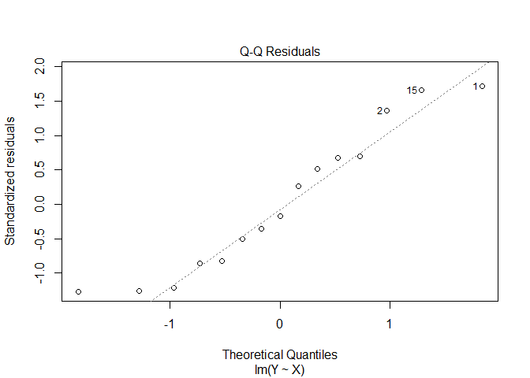

```r
plot(model,2)
```

# UJI FORMAL NORMALITAS SISAAN

H0: Sisaan menyebar normal H1: Sisaan tidak menyebar normal

```r
ks.test(model$residuals, "pnorm", mean=mean(model$residuals), sd=sd(model$residuals))
```

```
##
##  Exact one-sample Kolmogorov-Smirnov test
##
## data:  model$residuals
## D = 0.12432, p-value = 0.9521
## alternative hypothesis: two-sided
```

```r
shapiro.test(model$residuals)
```

```
##
##  Shapiro-Wilk normality test
##
## data:  model$residuals
## W = 0.92457, p-value = 0.226
```

Terima H0, karena p-value > 0.05. Maka, sisaan menyebar normal.

# UJI FORMAL KONDISI GAUSS-MARKOV

# Nilai harapan sisaan sama dengan nol

H0: mu = 0 H1: mu ≠ 0

```r
t.test(model$residuals,mu = 0,conf.level = 0.95)
```

```
##
##  One Sample t-test
##
## data:  model$residuals
## t = -4.9493e-16, df = 14, p-value = 1
## alternative hypothesis: true mean is not equal to 0
## 95 percent confidence interval:
##  -3.143811  3.143811
## sample estimates:
##     mean of x
## -7.254614e-16
```

Dengan menggunakan t-test, kesimpulannya terima H0 karena p-value > 0.05. Jadi, benar bahwa nilai harapan sisaan sama dengan nol.

# Ragam sisaan homogen

H0: Ragam sisaan homogen H1: Ragam sisaan tidak homogen

```r
bptest(model)
```

```
##
##  studentized Breusch-Pagan test
##
## data:  model
## BP = 0.52819, df = 1, p-value = 0.4674
```

```r
ncvTest(model)
```

```
## Non-constant Variance Score Test
## Variance formula: ~ fitted.values
## Chisquare = 0.1962841, Df = 1, p = 0.65774
```

Baik pada studentized Breusch-Pagan test atau Non-constant Variance Score Test, kesimpulan yang dapat ditarik adalah tak tolak atau terima H0 karena p-value > alpha = 0.05. Maka, ragam sisaan homogen.

# Sisaan saling bebas

H0: Sisaan saling bebas H1: Sisaan tidak saling bebas

```r
runs.test(model$residuals)
```

```
##
##  Runs Test
##
## data:  model$residuals
## statistic = -2.7817, runs = 3, n1 = 7, n2 = 7, n = 14, p-value =
## 0.005407
## alternative hypothesis: nonrandomness
```

```r
dwtest(model)
```

```
##
##  Durbin-Watson test
##
## data:  model
## DW = 0.48462, p-value = 1.333e-05
## alternative hypothesis: true autocorrelation is greater than 0
```

Baik pada Runs Test atau Durbin Watson Test, kesimpulan yang didapatkan adalah tolak H0 karena p-value < 0.05, maka sisaan tidak saling bebas (ada autokorelasi).

# TRANSFORMASI DATA

Melakukan transformasi dengan menjadikan peubah Y menjadi yt dimana yt merupakan hasil akar dari Y dan peubah X menjadi xt dimana xt merupakan hasil akar dari X.

```r
yt = sqrt(data$Y)
xt = sqrt(data$X)
```

# Pemeriksaan Asumsi dan Model Regresi

# plot xt dan yt

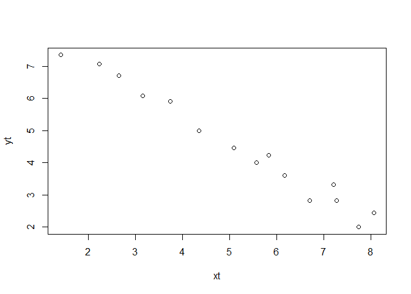

```r
plot(x = xt, y = yt)
```

```r
model.t1 = lm(formula = yt ~ xt)
summary(model.t1)
```

```
##
## Call:
## lm(formula = yt ~ xt)
##
## Residuals:
##      Min       1Q   Median       3Q      Max
## -0.42765 -0.17534 -0.05753  0.21223  0.46960
##
## Coefficients:
##             Estimate Std. Error t value Pr(>|t|)
## (Intercept)  8.71245    0.19101   45.61 9.83e-16 ***
## xt          -0.81339    0.03445  -23.61 4.64e-12 ***
## ---
## Signif. codes:  0 '***' 0.001 '**' 0.01 '*' 0.05 '.' 0.1 ' ' 1
##
## Residual standard error: 0.2743 on 13 degrees of freedom
## Multiple R-squared:  0.9772, Adjusted R-squared:  0.9755
## F-statistic: 557.3 on 1 and 13 DF,  p-value: 4.643e-12
```

```r
dwtest(model.t1)
```

```
##
##  Durbin-Watson test
##
## data:  model.t1
## DW = 2.6803, p-value = 0.8629
## alternative hypothesis: true autocorrelation is greater than 0
```

$$\hat Y = (8.71245-0.81339x^½)^2+e$$

# plot xt dan y

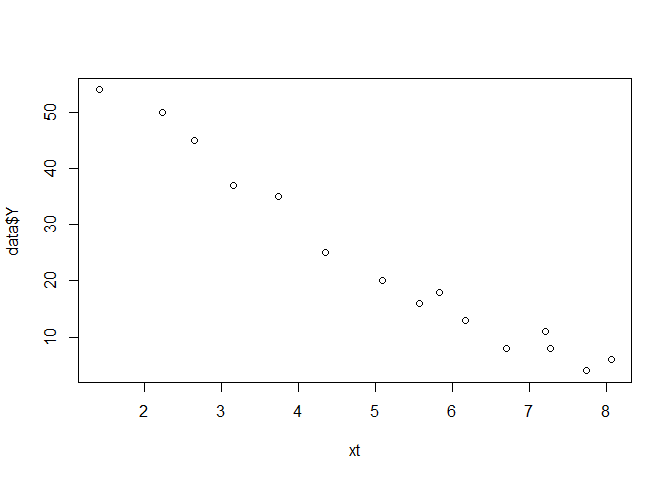

```r
plot(x = xt, y = data$Y)
```

```r
model.t2 = lm(formula = data$Y ~ xt)
summary(model.t2)
```

```
##
## Call:
## lm(formula = data$Y ~ xt)
##
## Residuals:
##     Min      1Q  Median      3Q     Max
## -4.4518 -2.8559  0.7657  2.0035  5.2422
##
## Coefficients:
##             Estimate Std. Error t value Pr(>|t|)
## (Intercept)  63.2250     2.2712   27.84 5.67e-13 ***
## xt           -7.7481     0.4097  -18.91 7.68e-11 ***
## ---
## Signif. codes:  0 '***' 0.001 '**' 0.01 '*' 0.05 '.' 0.1 ' ' 1
##
## Residual standard error: 3.262 on 13 degrees of freedom
## Multiple R-squared:  0.9649, Adjusted R-squared:  0.9622
## F-statistic: 357.7 on 1 and 13 DF,  p-value: 7.684e-11
```

```r
dwtest(model.t2)
```

```
##
##  Durbin-Watson test
##
## data:  model.t2
## DW = 1.1236, p-value = 0.01422
## alternative hypothesis: true autocorrelation is greater than 0
```

# plot x dan yt

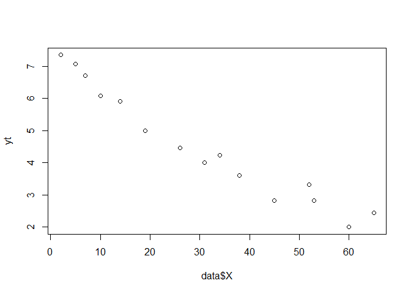

```r
plot(x = data$X, y = yt)
```

```r
model.t3 = lm(formula = yt ~ data$X)
summary(model.t3)
```

```
##
## Call:
## lm(formula = yt ~ data$X)
##
## Residuals:
##      Min       1Q   Median       3Q      Max
## -0.53998 -0.38316 -0.01727  0.36045  0.70199
##
## Coefficients:
##              Estimate Std. Error t value Pr(>|t|)
## (Intercept)  7.015455   0.201677   34.79 3.24e-14 ***
## data$X      -0.081045   0.005477  -14.80 1.63e-09 ***
## ---
## Signif. codes:  0 '***' 0.001 '**' 0.01 '*' 0.05 '.' 0.1 ' ' 1
##
## Residual standard error: 0.4301 on 13 degrees of freedom
## Multiple R-squared:  0.9439, Adjusted R-squared:  0.9396
## F-statistic: 218.9 on 1 and 13 DF,  p-value: 1.634e-09
```

```r
dwtest(model.t3)
```

```
##
##  Durbin-Watson test
##
## data:  model.t3
## DW = 1.2206, p-value = 0.02493
## alternative hypothesis: true autocorrelation is greater than 0
```